# Lab 2 key: Working with networks in `igraph`

Peter McMahan for [SOCI 424](https://soci424.netlify.app/)

## 1a.

> > Load the data directly from the internet using the following commands:

> ```r
> # load the igraph library
> library(igraph)
> # use the `read_graph()` function to load the data at the given web address.
> # (note: the `format` argument is necessary to tell igraph to expect a GraphML file )
> kenya <- read_graph('https://soci424.netlify.app/data/kenya.graphml',format='graphml')
> ```

## 1b.

> > Many objects in R have pretty good default visualizations, and `igraph` graph objects are no exception. Try plotting the `kenya` network using the `plot()` function. What kind of structure can you see? Are there distinct clusters in the network? Do some nodes seem more central than others? (*Note: each time you use the `plot()` function the network will look a little bit different. Sometimes plotting multiple times will emphasize different aspects of the network!*)

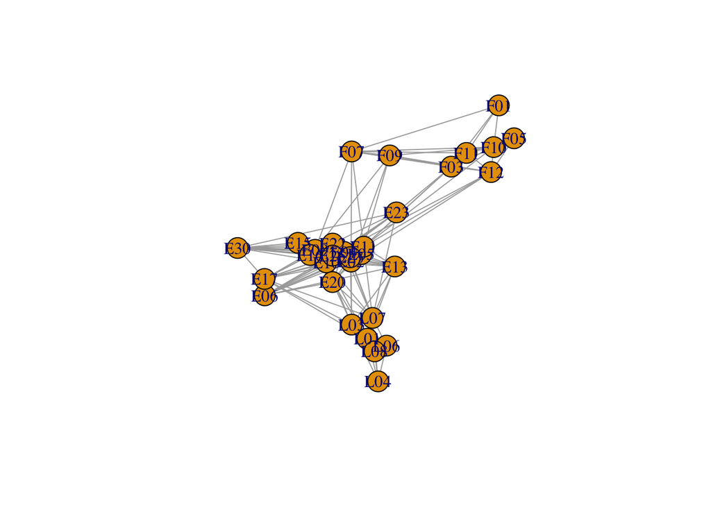

> ```r
> plot(kenya)
> ```

> As first impression, this network seems to be relatively well-connected, and to consist of maybe three major clusters. One cluster (the one with nodes labeled with “E”) looks like it is more ‘central’ than the other two, acting as a bridge connecting the other clusters.

## 1c.

> > Visualization is all well and good, but frequently we can tell more about a network by looking at some *measures*.
> > - Use the `vcount()` (vertex count) and `ecount()` (edge count) functions to report the number of people in the network and the number of relations depicted in the network.

> ```r
> vcount(kenya)
> ```

> ```
> ## [1] 31
> ```

> ```r
> ecount(kenya)
> ```

> ```
> ## [1] 174
> ```

> The network has 31 people (vertices) and 174 relations (edges).
> > - Use the function `is_directed()` to decide whether this is a *directed* or *undirected* network. Does the answer make sense, given the type of data the network contains? Why or why not?

> ```r
> is_directed(kenya)
> ```

> ```
> ## [1] FALSE
> ```

> The network is undirected. This makes sense because the relation depicted in the network (time spent with one another) is necessarily symmetric. If person A spends 5 minutes in the same room as person B, then person B must also have spent 5 minutes with person A.

## 1d.

> > The network plot above is somewhat deceptive, in that it shows all of the ties in the network as identical. In fact, it is showing a tie whenever two people have spent at least one minute within close proximity of each other. But many pairs spent much more time than that. This information is stored in an *edge attribute* that, in this case, is called “weight”. Use the command `E(kenya)$weight` to examine the number of minutes represented by each edge in the network.

> ```r
> E(kenya)$weight
> ```

> ```
> ##   [1] 200 295 182   6   3   1  36 135  67  80  83 124   1 137  96 409 184   4
> ##  [19]  18  43  16  57  23   1   1  39  13  57  15  26  48   8  22 125  28 342
> ##  [37]  75  26  19   1   1   2  15   5  15   4  24   7  10   4   6   4  24 138
> ##  [55]  29 102 119  28  32 104   2   4   1   6  29 335 179 208   1 199 188  76
> ##  [73]  21  38 122   6  32 154   3 109 271 142   2  26  84 166  25   6  99   4
> ##  [91]   9  42 157   4   1   5  12   1   6   8   8   9   1   5   2   1  28   1
> ## [109]   4   1   1   1   1   3   1   1   1   7  33   2   5  30 302   1   7   1
> ## [127]  10 236  21   1  85   1   1   1  30   1   3   2  22   5   1   1   3   2
> ## [145]   4   7   1   2   4   1 139  19   1 279   9   2   7   1  12   1   5   3
> ## [163]   1   3   1  81  96   1  38 113   3   1 241  33
> ```

> > - Does it seem like most of these edges represent a substantial amount of face-to-face interaction?

> Many of these edges appear to represent very minimal interaction. For instance, 65 (37%) of the edges represent less than five minutes of interaction, while fully 38 (22%) of the edges indicate only one minute of co-presence. Thus many of the edges represent a relatively *in*substantial amount of face-to-face interaction.
> > - What is the largest amount of time a pair of people spend near each other? (*You may want to use the `max()` function*)

> ```r
> max(E(kenya)$weight)
> ```

> ```
> ## [1] 409
> ```

> ```r
> E(kenya)[ weight == max(weight) ]
> ```

> ```
> ## + 1/174 edge from 2f89cb0 (vertex names):
> ## [1] E04--E11
> ```

> > - **Bonus**: Use the command `sum(E(kenya)$weight >= 60)` to see how many pairs spent at least 60 minutes with each other over the three days. Can you explain what that command works?

> ```r
> sum(E(kenya)$weight >= 60)
> ```

> ```
> ## [1] 43
> ```

> There are 43 pairs who spent at least an hour with each other. This command works because `E(kenya)$weight >= 60` returns a vector of `TRUE` and `FALSE` values. When you take the sum of a vector like this it treats the `TRUE` values as `1` and the `FALSE` values as `0`, so the result will be the number of `TRUE` values. Taking the sum of a logical vector is a common trick in R to count the frequency of some condition in a vector.

## 1e.

> > This network also has *vertex attributes*, which represents information about the individual people in the network. You can see what vertex attributes a network has recorded using the command `vertex_attr_names(kenya)`.

> ```r
> vertex_attr_names(kenya)
> ```

> ```
> ## [1] "name"      "household" "age"       "age_cat"   "gender"    "id"
> ```

> > - Try using the command `V(kenya)$age`. What does it tell you about the people in this network?

> ```r
> V(kenya)$age
> ```

> ```
> ##  [1] "0–5"   "6–14"  "0–5"   "20–49" "6–14"  "0–5"   "6–14"  "20–49" "20–49"
> ## [10] "6–14"  "20–49" "20–49" "6–14"  "20–49" "6–14"  "6–14"  "20–49" "20–49"
> ## [19] "20–49" "0–5"   "15–19" "15–19" "6–14"  "20–49" "50+"   "0–5"   "20–49"
> ## [28] "15–19" "6–14"  "20–49" "20–49"
> ```

> It looks like each person was put into one of five age ranges. One way to get a summary of a categorical variable like this is with the `table()` function:

> ```r
> table( V(kenya)$age )
> ```

> ```
> ##
> ##   0–5 15–19 20–49   50+  6–14
> ##     5     3    13     1     9
> ```

> From this output we can tell that almost half of the people (13) are between the ages of 20 and 49. We can also see that there are a number of children, but only one person 50 or more years old.
> > - Now look at the `gender` attribute. What does it tell you?

> ```r
> V(kenya)$gender
> ```

> ```
> ##  [1] "M" "M" "M" "M" "M" "M" "F" "F" "M" "F" "F" "M" "F" "F" "M" "F" "F" "F" "M"
> ## [20] "F" "M" "M" "M" "F" "F" "M" "F" "M" "F" "F" "F"
> ```

> ```r
> table( V(kenya)$gender )
> ```

> ```
> ##
> ##  F  M
> ## 16 15
> ```

> Each person in the network is in one of two gender categories, presumably *male* and *female*. The distribution is approximately even between the two categories.
> > - What other vertex attributes are there? Can you tell what they indicate?

> There is also a `name` attribute, which consists of a letter followed by two digits. This was used as the label in the plot above. The `household` variable takes one of three values, 2,3 and 5, presumably indicating which of the three households the people are in. The `age_cat` attribute corresponds with the `age` attribute, giving a numeric label to the five age categories mentioned above. Finally, there is an `id` attribute that seems to simply give each vertex a unique identifier (e.g. “n20”).

## 2a.

> > First, we will visualize the strength of the relations between actors (measured by the amount of time they spend around each other) by adjusting the edge width. Unless you tell it otherwise, `igraph` draws the edges with a width of 1. Use the following commands to set the `width` attribute of the edges in `kenya` to be equal to the `weight` attribute you looked at in **1d**:

> ```r
> E(kenya)$width <- E(kenya)$weight
> ```

> > - Now plot the network with `plot(kenya)`. *Ack!* What happened? Looking at your response to **1d**, and knowing that the default edge width is 1, can you tell why the graph looks like it does?

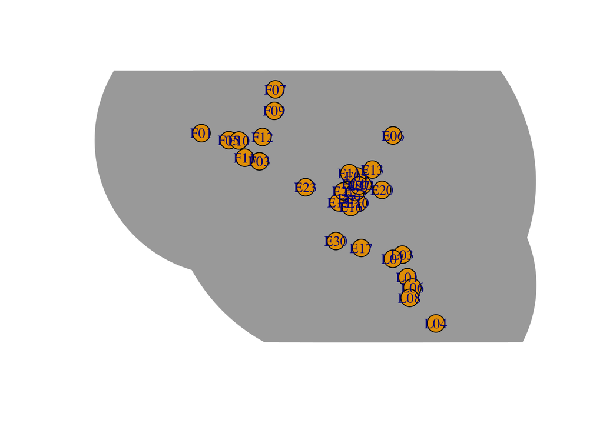

> ```r
> plot(kenya)
> ```

> This is obviously a bad visualization. Because some of the edges have such large weights, those edges end up being huge in the plot. When an line representing an edge is wider than it is long it just obscures all of the other edges.
> > - This is a common problem with network visualizations: the “strongest” edges are often *much* stronger than the “weakest” edges. One way around this is to use a *transformation* that will shrink thick edges more than it will shrink thin edges. One transformation that often works well is *square root*. Use the `sqrt()` function to change the above command so that the width of the edges is the square root of the number of minutes a pair of people spent together.

> ```r
> # set each edge width to be the square root of that edge's `weight`
> E(kenya)$width <- sqrt( E(kenya)$weight )
> ```

> > - Plot the network again with the re-calculated edge widths. Does it look better? Can you differentiate between the pairs of actors that spent a lot of time together and those that spent little time together?

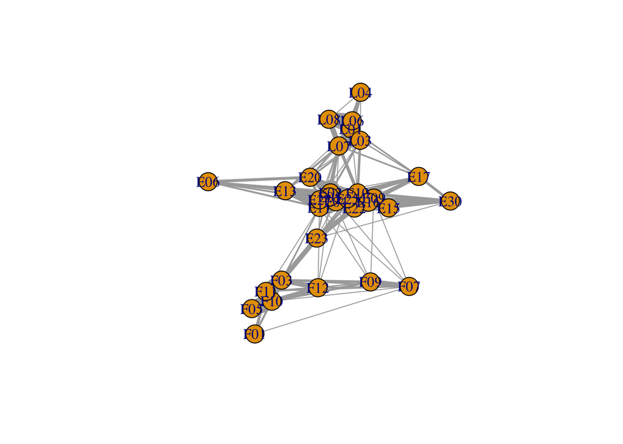

> ```r
> plot(kenya)
> ```

> This looks *much* better. The thickness of the edges can now help differentiate between the different pairs that spent a large amount (thick line) and a small amount (thin line) of time together.

## 2b.

> > The default labels on the vertices (retrieved from the `name` attribute) are not very informative. Let’s label them with the household they live in instead.
> > - Use the `V()` function to set the `label` attribute of the vertices with the `household` attribute. (*Hint: this will look very similar to the command to set edge widths from **2a***)

> ```r
> V(kenya)$label <- V(kenya)$household
> ```

> > - Re-plot the network to see if the numeric household labels are visible.

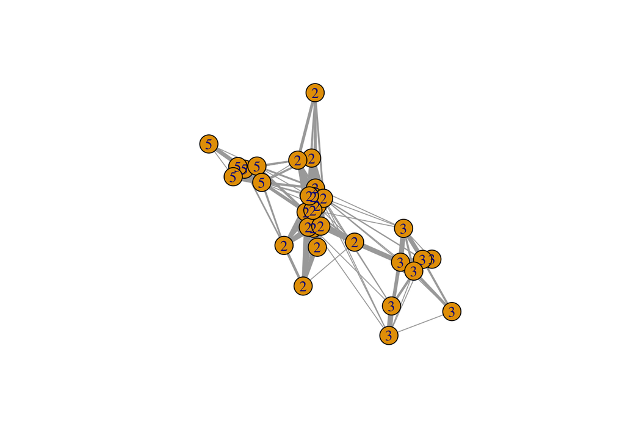

> ```r
> plot(kenya)
> ```

> The vertices are now clearly labeled with one of three household numbers (2, 3, or 5).

## 2c.

> > Next, we will visualize the age of the actors in the network using the size of the vertex. By default, `igraph` uses a size of 15 for its vertices (for some reason…). Let’s start by representing the youngest people with smaller nodes.

> ```r
> # first, we need to set a specific size for all of the vertices.
> # We'll stick with the default of 15
> V(kenya)$size <- 15
> # Next, the square-bracket notation [] lets us set an attribute value
> # for only a subset of the vertices.
> # Let's set the youngest vertices (category 0) size to 5.
> V(kenya)$size[V(kenya)$age_cat == 0] <- 5
> ```

> > - Plot the network with these vertex sizes. Can you see some of the youngest vertices represented by smaller circles?

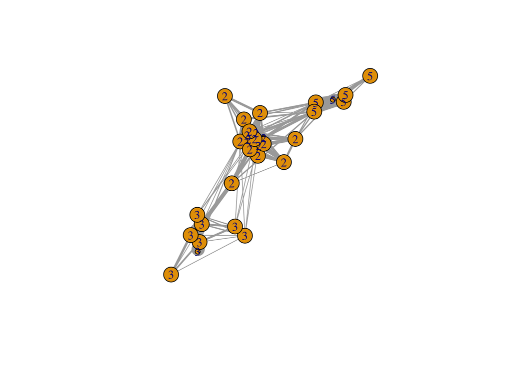

> ```r
> plot(kenya)
> ```

> Yes, a few of the vertices are much smaller than in previous plots. (Some of them may be obscured by other vertices).
> > - Now assign sizes for the rest of the age categories, using the command above as a template. You will need to use some trial and error to find good sizes! (When you are done you should be able to see clusters by age within the three different households.)

> The full set of commands to size the vertices by age follows. There is no ‘right’ answer for the set of sizes, just whatever you think best shows the differences. In the resulting plot, there is a clear cluster of children in household 2 that spend a lot of time together.

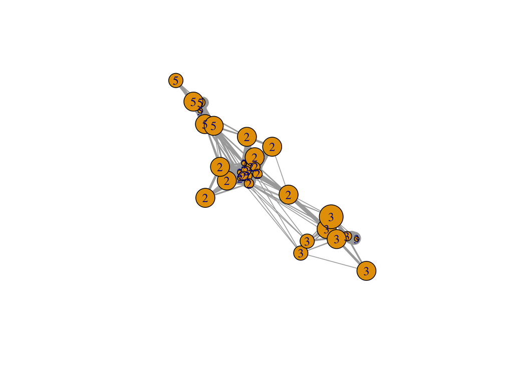

> ```r
> V(kenya)$size <- 15
> V(kenya)$size[V(kenya)$age_cat == 0] <- 5
> V(kenya)$size[V(kenya)$age_cat == 1] <- 10
> V(kenya)$size[V(kenya)$age_cat == 2] <- 15
> V(kenya)$size[V(kenya)$age_cat == 3] <- 20
> V(kenya)$size[V(kenya)$age_cat == 4] <- 25
> plot(kenya)
> ```

## 2d.

> > **Bonus question:** Use the `shape` vertex attribute to represent the ‘`M`’ gender with circles and the ‘`F`’ gender with squares. (`igraph` recognizes the strings `"circle"` and `"square"` for setting vertex shapes)

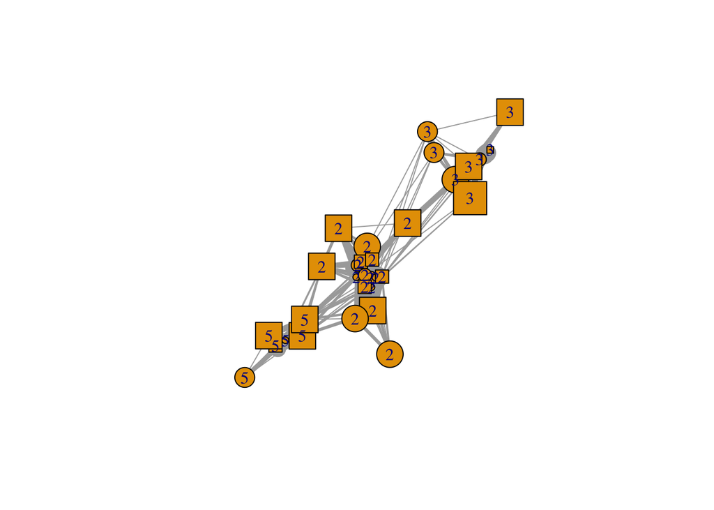

> ```r
> # set them all to circle
> V(kenya)$shape <- 'circle'
> V(kenya)$shape[V(kenya)$gender=="F"] <- 'square'
> plot(kenya)
> ```

## 3a.

> > We will use the function `cluster_optimal()` to find maximum-modularity clusters.
> > - Type the command `?cluster_optimal` into the R console to get help on this function and take a moment to read it. If we do not specify an edge weight when we call the function, will `igraph` use the `weight` edge attribute in its calculations?

> `?cluster_optimal` brings up the documentation for the `cluster_optimal()` function. Under the “Arguments” section, it says that `weights` is the “Optional positive weight vector for optimizing weighted modularity. If the graph has a ‘weight’ edge attribute, then this is used by default. Supply ‘NA’ to ignore the weights of a weighted graph. Larger edge weights correspond to stronger connections.”

> Thus, since our network *does* have a ‘weight’ edge attribute, this tells us that it will take those weights into account by default when calculating the modularity.
> > - Use the `cluster_optimal()` function to calculate the clusters, and store the result in a variable named `clust`.

> ```r
> clust <- cluster_optimal(kenya)
> ```

> *Note: for some of you the `cluster_optimal()` function was not working. The following command uses an approximate version of modularity maximization instead and produces the exact same results:

> ```r
> clust <- cluster_fast_greedy(kenya)
> ```

> > - What can you tell about the clusters just by typing `clust` into the console and looking at the resulting output?

> The previous command calculated the clusters but did not give us any information on the clusters. Typing `clust` on its own will show us some summary information about the clusters it found:

> ```r
> clust
> ```

> ```
> ## IGRAPH clustering fast greedy, groups: 4, mod: 0.38
> ## + groups:
> ##   $`1`
> ##   [1] "E02" "E04" "E05" "E06" "E11" "E13" "E20" "E25" "E27"
> ##
> ##   $`2`
> ##   [1] "E23" "F01" "F03" "F05" "F07" "F09" "F10" "F11" "F12"
> ##
> ##   $`3`
> ##   [1] "L01" "L03" "L04" "L06" "L07" "L08"
> ##
> ##   $`4`
> ##   + ... omitted several groups/vertices
> ```

> This tells us the clustering algorithm that was used (“fast greedy”), the number of clusters it found (4), the modularity (0.38), and lists the membership of some of the clusters.

## 3b.

> > Now we will represent the clusters with colors in the network visualization. This will require a few steps.
> > - First assign a `cluster` attribute to each vertex using the command `V(kenya)$cluster <- membership(clust)`. (The `membership()` function assigns each cluster a number, and uses that number to indicate the cluster that each vertex is in.)

> ```r
> V(kenya)$cluster <- membership(clust)
> ```

> > - Now, set the `color` attribute of each vertex according to the cluster it is in. Make cluster 1 `'red'`, cluster 2 `'purple'`, cluster 3 `'white'`, and cluster 4 `'gray'`. You can use different colors if you want to. (*Note: since you have already calculated the cluster membership, this code will look very similar to the code you used for **2c** and **2d** above.*)

> ```r
> V(kenya)$color[V(kenya)$cluster == 1] <- 'red'
> V(kenya)$color[V(kenya)$cluster == 2] <- 'purple'
> V(kenya)$color[V(kenya)$cluster == 3] <- 'white'
> V(kenya)$color[V(kenya)$cluster == 4] <- 'gray'
> ```

> > - Finally, plot your network again. You should see each vertex colored according to the cluster it is in. Do you see any obvious patterns to the clustering based on the vertex characteristics?

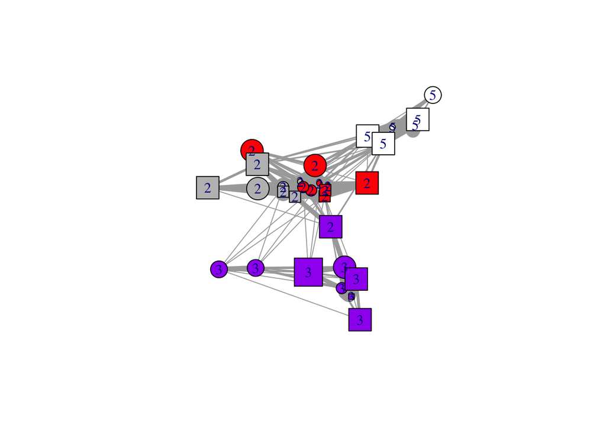

> ```r
> plot(kenya)
> ```

> The clusters clearly align with households. However household 2 consists of two distinct clusters, and one member of household 2 seems to spend more time with members of household 3 than household 2. (Note, since the specific cluster labels are arbitrary (there is no principled reason that cluster 1 was not labeled as cluster 2), you may have different colors on your clusters than me.)